# Reproducible Research - Peer Assessment 1

Author: Leslie McIntosh  
R Version: 3.1.1  
R Packages Required:

- ggplot2
- plyr
- Hmisc
- rrcovNA

### Loading and preprocessing the data

Load the data into R. Note that I unzipped the data file before I imported it.

```r
activity <- read.table("~/RepData_PeerAssessment1/activity.csv", header=TRUE, sep = ",")
#Convert date formatting
activity$date <- as.Date(activity$date)
#Load required r packages
library(ggplot2)
library(plyr)
library(Hmisc)
library(plyr)
library(rrcovNA)
```

### What is the mean total number of steps taken per day?

Make a histogram of the total number of steps taken each day

```
## stat_bin: binwidth defaulted to range/30. Use 'binwidth = x' to adjust this.
```

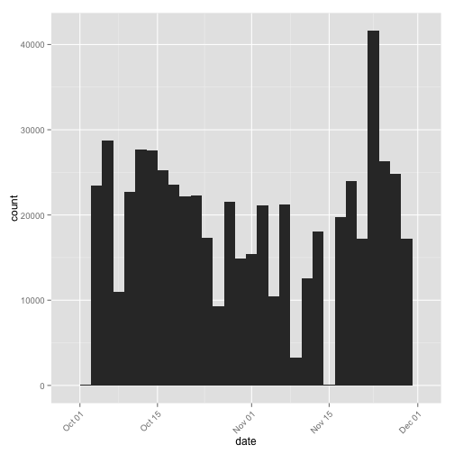

```r
#library(ggplot2)
q <- qplot(date, data=activity, weight=steps, geom="histogram")
q + theme(axis.text.x = element_text(angle = 45, hjust = 1))
```

```r
#library(plyr)
ddply(activity, "date", summarise, mean=mean(steps), median=median(steps))
```

```
##          date       mean median
## 1  2012-10-01         NA     NA
## 2  2012-10-02  0.4375000      0
## 3  2012-10-03 39.4166667      0
## 4  2012-10-04 42.0694444      0
## 5  2012-10-05 46.1597222      0
## 6  2012-10-06 53.5416667      0
## 7  2012-10-07 38.2465278      0
## 8  2012-10-08         NA     NA
## 9  2012-10-09 44.4826389      0
## 10 2012-10-10 34.3750000      0
## 11 2012-10-11 35.7777778      0
## 12 2012-10-12 60.3541667      0
## 13 2012-10-13 43.1458333      0
## 14 2012-10-14 52.4236111      0
```

[output cut: 47 more lines]

### What is the average daily activity pattern?

Make a time series plot (i.e. type = “l”) of the 5-minute interval (x-axis) and the average number of steps taken, averaged across all days (y-axis)

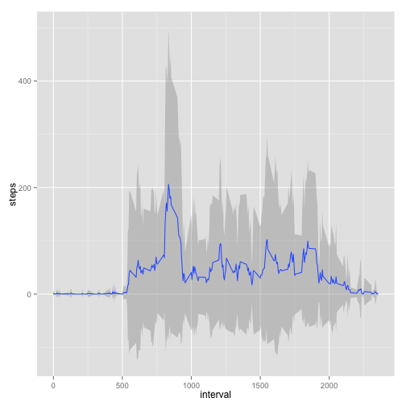

```r
#library(Hmisc)
ggplot(activity,aes(x=interval,y=steps)) +
        stat_summary(fun.data ="mean_sdl", mult=1, geom = "smooth")
```

```r
#library(plyr)
avg_interval <- ddply(activity, .(interval), summarize,
      mean = mean(steps, na.rm=TRUE))
```

[output not shown]

```
## Error in eval(expr, envir, enclos): argument "by" is missing, with no default
```

```r
avg_interval[which(avg_interval$mean == max(avg_interval$mean)), ]
```

[output not shown]

```
## Error in eval(expr, envir, enclos): object 'avg_interval' not found
```

### Imputing Missing Values

Calculate and report the total number of missing values in the dataset (i.e. the total number of rows with NAs)

```r
sum(!complete.cases(activity))
```

```
## [1] 2304
```

Devise a strategy for filling in all of the missing values in the dataset. The strategy does not need to be sophisticated. For example, you could use the mean/median for that day, or the mean for that 5-minute interval, etc.

Create a new dataset that is equal to the original dataset but with the missing data filled in.

```
    I used the rrcovNA package for imputation as described in
    http://www.unt.edu/rss/class/Jon/Benchmarks/MissingValueImputation_JDS_Nov2010.pdf
```

```r
#library(rrcovNA)

summary(activity)
```

```
##      steps             date               interval
##  Min.   :  0.00   Min.   :2012-10-01   Min.   :   0.0
##  1st Qu.:  0.00   1st Qu.:2012-10-16   1st Qu.: 588.8
##  Median :  0.00   Median :2012-10-31   Median :1177.5
##  Mean   : 37.38   Mean   :2012-10-31   Mean   :1177.5
##  3rd Qu.: 12.00   3rd Qu.:2012-11-15   3rd Qu.:1766.2
##  Max.   :806.00   Max.   :2012-11-30   Max.   :2355.0
##  NA's   :2304
```

```r
activity_imp <- impSeq(activity)
activity_imp <- data.frame(activity_imp)
activity_imp$date <- as.Date(activity_imp$date, origin="1970-01-01")
summary(activity_imp)
```

```
##      steps             date               interval
##  Min.   :  0.00   Min.   :2012-10-01   Min.   :   0.0
##  1st Qu.:  0.00   1st Qu.:2012-10-16   1st Qu.: 588.8
##  Median :  0.00   Median :2012-10-31   Median :1177.5
##  Mean   : 37.39   Mean   :2012-10-31   Mean   :1177.5
##  3rd Qu.: 34.43   3rd Qu.:2012-11-15   3rd Qu.:1766.2
##  Max.   :806.00   Max.   :2012-11-30   Max.   :2355.0
```

```
## stat_bin: binwidth defaulted to range/30. Use 'binwidth = x' to adjust this.
```

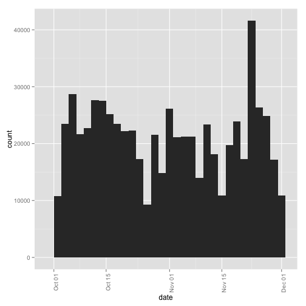

```r
#library(ggplot2)
q2 <- qplot(date, data=activity_imp, weight=steps, geom="histogram")
q2 + theme(axis.text.x = element_text(angle = 90, hjust = 1))
```

```r
#library(plyr)
ddply(activity_imp, "date", summarise, mean=mean(steps), median=median(steps))
```

```
##          date       mean   median
## 1  2012-10-01 37.0234056 37.02341
## 2  2012-10-02  0.4375000  0.00000
## 3  2012-10-03 39.4166667  0.00000
## 4  2012-10-04 42.0694444  0.00000
## 5  2012-10-05 46.1597222  0.00000
## 6  2012-10-06 53.5416667  0.00000
## 7  2012-10-07 38.2465278  0.00000
## 8  2012-10-08 37.1080158 37.10802
## 9  2012-10-09 44.4826389  0.00000
## 10 2012-10-10 34.3750000  0.00000
## 11 2012-10-11 35.7777778  0.00000
## 12 2012-10-12 60.3541667  0.00000
## 13 2012-10-13 43.1458333  0.00000
## 14 2012-10-14 52.4236111  0.00000
```

[output cut: 47 more lines]

### Assess weekend influence

Create a new factor variable in the dataset with two levels – “weekday” and “weekend” indicating whether a given date is a weekday or weekend day.

```r
activity_imp$weekdays <- weekdays(activity_imp$date)

weekend_l <- c("Saturday", "Sunday")
activity_imp$weekend <- ifelse(activity_imp$weekdays %in% weekend_l,
                        c("weekend"), c("weekday"))
table(activity_imp$weekdays, activity_imp$weekend)
```

```
##
##             weekday weekend
##   Friday       2592       0
##   Monday       2592       0
##   Saturday        0    2304
##   Sunday          0    2304
##   Thursday     2592       0
##   Tuesday      2592       0
##   Wednesday    2592       0
```

Make a panel plot containing a time series plot (i.e. type = “l”) of the 5-minute interval (x-axis) and the average number of steps taken, averaged across all weekday days or weekend days (y-axis).

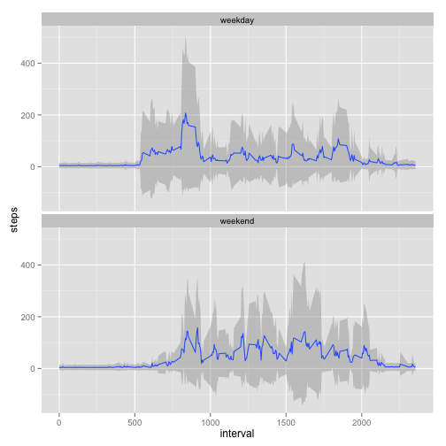

```r
ggplot(activity_imp,aes(x=interval,y=steps)) +
        stat_summary(fun.data ="mean_sdl", mult=1, geom = "smooth") +
        facet_wrap(~ weekend, ncol=1)
```